# 204.3. Astrometric Calibration

For the Rubin Science Platform at data.lsst.cloud.  
Data Release: [Data Preview 2](https://dp2.lsst.io/)  
Container Size: Large  
LSST Science Pipelines version: r30.0.10  
Last verified to run: 2026-07-22  
Repository: github.com/lsst/tutorial-notebooks  
DOI: 10.11578/rubin/dc.20250909.20

**Learning objective:** To understand astrometric calibration in DP2, including how to access the World Coordinate System (WCS) for coadd images and centroid uncertainties.

**LSST data products:** `deep_coadd.sky_projection`, `object`.

**Packages:** `lsst.daf.butler`, `lsst.geom`, `lsst.utils.plotting`, `astropy`, `numpy`, `matplotlib`.

**Credit:** Originally developed by the Rubin Community Science team. Please consider acknowledging them if this notebook is used for the preparation of journal articles, software releases, or other notebooks.

**Get Support:** Everyone is encouraged to ask questions or raise issues in the [Support Category](https://community.lsst.org/c/support) of the Rubin Community Forum. Rubin staff will respond to all questions posted there.

## 1. Introduction

The World Coordinate System (WCS), or astrometric solution, defines how pixel positions in an image map to celestial coordinates—right ascension and declination (RA, Dec).

The LSST Science Pipelines perform astrometric calibration in two main stages.

1. An initial WCS is estimated using a static camera model and refined per detector and exposure by matching sources to [Gaia DR3](https://ui.adsabs.harvard.edu/abs/2023A&A...674A...1G/abstract), achieving an accuracy of approximately 10-20 milliarcseconds—sufficient for associating sources across visits.
2. A more precise solution is derived using overlapping visits with the `GBDES` ([Bernstein, Armstrong, Plazas et al., 2017](https://ui.adsabs.harvard.edu/abs/2017PASP..129g4503B/abstract)) algorithm. This model fits two components: a per-detector static map (capturing camera distortions and the physical layout of the camera) and a per-visit dynamic map (accounting for time-varying effects like atmospheric refraction). The solution can optionally include proper motion, parallax, and corrections for differential chromatic refraction (DCR).

For DP2, the astrometric calibration follows the DP1 method with two main additions (see the DP2 paper, [RTN-115](https://rtn-115.lsst.io/)). A joint calibration is performed on all visits in a given band that overlap a region of the sky—an order-3 HEALPix pixel in DP2, rather than the tract used in DP1—by associating the isolated point sources shared among the overlapping visits and matching them to Gaia DR3 with the `gbdes` package. In addition, the wave-like residuals left by atmospheric turbulence are modeled with a Gaussian Process ([Léget et al. 2021](https://ui.adsabs.harvard.edu/abs/2021A%26A...650A..81L/abstract)) and combined with the `gbdes` model, significantly improving the solution (see [DMTN-324](https://dmtn-324.lsst.io/)). The proper motions and parallaxes of the calibration stars are fit jointly (reference epoch 2024.9); differential chromatic refraction and lateral color are not yet included and will be added in future data releases.

This is a Data Preview 2 (DP2) tutorial, using data from the LSST Science Camera (LSSTCam). Two aspects differ from the DP1 (LSSTComCam) version:

- The WCS is stored as an [AST](https://ui.adsabs.harvard.edu/abs/2016A%26C....15...33B/abstract)-based `SkyWcs` object, not a plain FITS WCS. A FITS-standard representation is also written to the image headers so that tools such as `astropy` can read the WCS. For a coadd this FITS WCS is exact, because the coadd is built on an exact tangent-plane (TAN) projection; for a visit image it is only an approximation to the full `SkyWcs`, slightly less accurate near the edges of the LSSTCam focal plane (see [DMTN-339](https://dmtn-339.lsst.io/)).
- DP2 coadds use the new `lsst.images` data model, in which the WCS is an `lsst.images` `SkyProjection` (with `pixel_to_sky`, `sky_to_pixel`, and `as_fits_wcs` methods). The projection can be read on its own with a Butler component query (`deep_coadd.sky_projection`), without loading the full image.

**References**

- [RTN-115: The Vera C. Rubin Observatory Data Preview 2](https://rtn-115.lsst.io/)
- [DMTN-266: Astrometric Calibration in the LSST Pipeline](https://dmtn-266.lsst.io/DMTN-266.pdf)
- [DMTN-324: Early astrometric residuals characterization of LSSTCam](https://dmtn-324.lsst.io/)
- [DMTN-339: Challenges serializing Rubin Observatory data products](https://dmtn-339.lsst.io/)
- [PSTN-019: The LSST Science Pipelines Software](https://pstn-019.lsst.io/)
- [RTN-095: The Vera C. Rubin Observatory Data Preview 1](https://rtn-095.lsst.io/)

**Related tutorials:** *The Monster* reference catalog, used as the astrometric reference, is covered in another DP2 200-level calibration tutorial.

### 1.1. Import packages

Import `numpy`, a fundamental package for scientific computing with arrays in Python (numpy.org), and `matplotlib`, a comprehensive library for data visualization ([matplotlib.org](https://matplotlib.org/)).

From `astropy`, import units and celestial-coordinate handling ([astropy.org](https://www.astropy.org/)).

From the `lsst` package, import the Butler, geometry utilities, and standard plotting helpers from the LSST Science Pipelines ([pipelines.lsst.io](https://pipelines.lsst.io/)).

```python
import numpy as np
import matplotlib.pyplot as plt
import astropy.units as u
from astropy.coordinates import SkyCoord

from lsst.daf.butler import Butler
from lsst.images import SkyProjection, DetectorFrame, Box
from lsst.utils.plotting import (get_multiband_plot_colors,
                                 get_multiband_plot_linestyles)
```

### 1.2. Define parameters and functions

Instantiate the Butler with the DP2 repository and collection.

```python
butler = Butler("dp2", collections="dp2")
```

Get the standard per-band colors and linestyles.

```python
filter_colors = get_multiband_plot_colors()
filter_linestyles = get_multiband_plot_linestyles()
```

## 2. WCS for a coadd image

In DP2 a `deep_coadd` is stored in the new `lsst.images` data model (`CellCoadd`), and its WCS is an `lsst.images` `SkyProjection`. This section shows how to obtain a `SkyProjection` and use its methods; the visit-image case (Section 3) uses the same interface.

Define a particular location on the sky and a band. Use a position in the ELAIS-S1 deep drilling field, in degrees.

```python
ra_cen, dec_cen = 10.196, -44.134
my_band = 'i'
```

Find the tract and patch that contain the target position with a spatial Butler query on the `patch` dimension records (registry metadata only).

```python
patch_records = butler.query_dimension_records(
    "patch",
    where="skymap = :skymap AND patch.region OVERLAPS POINT(:ra, :dec)",
    bind={"skymap": "lsst_cells_v2", "ra": ra_cen, "dec": dec_cen})
my_tract = patch_records[0].dataId["tract"]
my_patch = patch_records[0].dataId["patch"]
print("tract:", my_tract, "| patch:", my_patch)
```

```
tract: 2877 | patch: 34
```

Read only the `sky_projection` and `bbox` components of the `deep_coadd` from the Butler; the full image is not loaded.

```python
data_id = {"band": my_band, "skymap": "lsst_cells_v2",
           "tract": my_tract, "patch": my_patch}
coadd_wcs = butler.get("deep_coadd.sky_projection", **data_id)
coadd_bbox = butler.get("deep_coadd.bbox", **data_id)
```

### 2.1. Convert between pixel and sky coordinates

The `SkyProjection` maps between pixel coordinates (in the tract pixel grid) and sky positions, which are `astropy` `SkyCoord` objects. Convert the target sky position to pixels, and back.

```python
target = SkyCoord(ra=ra_cen*u.deg, dec=dec_cen*u.deg)
xy = coadd_wcs.sky_to_pixel(target)
xy
```

```
XY(x=14656.538058947777, y=10504.271749935344)
```

```python
coadd_wcs.pixel_to_sky(x=xy.x, y=xy.y)
```

```
<SkyCoord (ICRS): (ra, dec) in deg
    (10.196, -44.134)>
```

### 2.2. Pixel scale

Compute the pixel scale (in arcseconds per pixel) by transforming two pixels one pixel apart and measuring their angular separation.

```python
sky_00 = coadd_wcs.pixel_to_sky(x=xy.x, y=xy.y)
sky_10 = coadd_wcs.pixel_to_sky(x=xy.x + 1, y=xy.y)
pixel_scale = sky_00.separation(sky_10).to(u.arcsec)
print(f"Pixel scale: {pixel_scale.value: .4f} arcsec/pixel")
```

```
Pixel scale:  0.2000 arcsec/pixel
```

### 2.3. FITS WCS

A FITS-standard WCS can be produced with `as_fits_wcs`, given the image bounding box. For a coadd this FITS WCS is exact, because the coadd is built on an exact tangent-plane (TAN) projection (see Section 1).

```python
fits_wcs_coadd = coadd_wcs.as_fits_wcs(coadd_bbox)
fits_wcs_coadd
```

```
WCS Keywords

Number of WCS axes: 2
CTYPE : 'RA---TAN' 'DEC--TAN'
CUNIT : 'deg' 'deg'
CRVAL : 10.169491525423737 -43.88429752066116
CRPIX : 3150.0 6150.0
CD1_1 CD1_2  : -5.5555555555553024e-05 0.0
CD2_1 CD2_2  : 0.0 5.555555555555367e-05
NAXIS : 3300  3300
```

## 3. WCS for a visit image

The per-detector WCS for every detector in a visit is collected in the `visit_summary` table. In DP2 the WCS stored there is a legacy `lsst.afw.geom.SkyWcs`; wrap it into an `lsst.images` `SkyProjection` with `from_legacy` to use the same interface as the coadd (Section 2). Once a `SkyProjection` is in hand, `pixel_to_sky`, `sky_to_pixel`, and the pixel-scale calculation work exactly as in Section 2.

**Important:** Visit images are not available in "Early DP2" but they will be available with the "Full DP2" release.

> **Note:** Once the Full DP2 release is available (see [RTN-011](https://rtn-011.lsst.io/)), the visit WCS will be accessible directly as `visit_image.sky_projection` (the same component-based access used for the coadd in Section 2), which will be the preferred method; the `visit_summary` approach shown here is used in the interim.

Find a visit and detector whose footprint overlaps the target position, using the `visit_detector_region` dimension records.

```python
detector_records = butler.query_dimension_records(
    "visit_detector_region",
    where="band.name = :band AND visit_detector_region.region OVERLAPS POINT(:ra, :dec)",
    bind={"band": my_band, "ra": ra_cen, "dec": dec_cen})
visit_id = detector_records[0].dataId["visit"]
detector_id = detector_records[0].dataId["detector"]
print("Using visit:", visit_id, "| detector:", detector_id)
```

```
Using visit: 2026010100038 | detector: 82
```

Get the `visit_summary` for this visit, and retrieve the legacy `SkyWcs` and bounding box for the chosen detector.

```python
visit_summary = butler.get("visit_summary", instrument="LSSTCam", visit=visit_id)
record = visit_summary.find(detector_id)
legacy_wcs = record.wcs
detector_bbox = Box.from_legacy(record.getBBox())
```

Wrap the legacy `SkyWcs` into an `lsst.images` `SkyProjection` with `from_legacy`. Build a `DetectorFrame` from the visit ID, detector ID, and bounding box (all available from the same `visit_summary` row).

```python
wcs_visit = SkyProjection.from_legacy(
    legacy_wcs,
    DetectorFrame(instrument="LSSTCam", visit=visit_id,
                  detector=detector_id, bbox=detector_bbox))
```

### 3.1. FITS approximation

The `pixel_to_sky`, `sky_to_pixel`, and pixel-scale methods behave exactly as for the coadd (Section 2). The one difference is the FITS WCS: for a visit image the true `SkyWcs` cannot be represented exactly in FITS, so `as_fits_wcs` returns a SIP approximation and must be called with `allow_approximation=True` (see Section 1).

```python
fits_wcs_visit = wcs_visit.as_fits_wcs(detector_bbox, allow_approximation=True)
fits_wcs_visit
```

```
WCS Keywords

Number of WCS axes: 2
CTYPE : 'RA---TAN-SIP' 'DEC--TAN-SIP'
CUNIT : 'deg' 'deg'
CRVAL : 10.195640728405449 -44.15321830027622
CRPIX : 2048.5 2002.5
CD1_1 CD1_2  : -4.5664821768378106e-05 -3.165696114864475e-05
CD2_1 CD2_2  : -3.1649358566663904e-05 4.567304467816654e-05
NAXIS : 4096  4004
```

## 4. Sky coordinates, errors, and astrometric accuracy

In the `source` and `object` catalogs, centroids are measured using the `SdssCentroid` algorithm, which operates in pixel coordinates. Once the centroid and its uncertainty are determined in pixels, the WCS transforms these measurements into right ascension and declination, and the uncertainties are propagated through this transformation.

### 4.1. Centroid uncertainties

Retrieve the centroid uncertainties and magnitudes for PSF stars from the `object` dataset for the tract. In DP2 the `Object` catalog is read directly from the Butler, which returns all objects in the tract.

```python
columns = ["refExtendedness",
           f"{my_band}_calib_psf_used",
           f"{my_band}_pixelFlags_inexact_psfCenter",
           f"{my_band}_raErr", f"{my_band}_decErr", f"{my_band}_psfFlux"]
object_data = butler.get("object", skymap="lsst_cells_v2",
                         tract=my_tract, parameters={"columns": columns})
```

Select point-like sources used in PSF modeling, keeping only those with finite centroid errors and positive flux.

```python
mask = ((np.asarray(object_data["refExtendedness"]) == 0.0)
        & np.asarray(object_data[f"{my_band}_calib_psf_used"])
        & ~np.asarray(object_data[f"{my_band}_pixelFlags_inexact_psfCenter"])
        & np.isfinite(np.asarray(object_data[f"{my_band}_raErr"]))
        & np.isfinite(np.asarray(object_data[f"{my_band}_decErr"]))
        & (np.asarray(object_data[f"{my_band}_psfFlux"]) > 0))
```

Convert the centroid errors from degrees to milliarcseconds using `astropy` units, and convert the PSF fluxes to AB magnitudes.

**Converting flux to AB magnitude.** Fluxes in the `Object` table are in nanojansky (nJy). Convert a flux $f$ to an AB magnitude with

$$m_{\mathrm{AB}} = -2.5\,\log_{10}\left(\frac{f}{3631\,\mathrm{Jy}}\right) = -2.5\,\log_{10}(f_{\mathrm{nJy}}) + 31.4,$$

where the constant $31.4$ is the AB zero point for fluxes in nanojansky ($3631\,\mathrm{Jy} = 3.631\times10^{12}\,\mathrm{nJy}$). Only positive fluxes have a defined magnitude—forced-photometry fluxes can be negative for faint sources—so the selection above keeps only sources with positive `{band}_psfFlux`.

```python
ra_err = (np.asarray(object_data[f"{my_band}_raErr"])[mask] * u.deg).to(u.mas).value
dec_err = (np.asarray(object_data[f"{my_band}_decErr"])[mask] * u.deg).to(u.mas).value
psf_flux = np.asarray(object_data[f"{my_band}_psfFlux"])[mask]
mag = -2.5 * np.log10(psf_flux) + 31.4
```

Plot the distribution of the propagated uncertainties on the centroids.

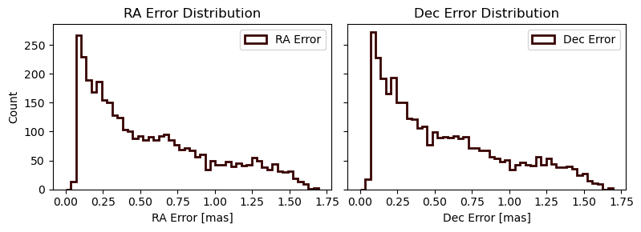

```python
max_err = max(ra_err.max(), dec_err.max())
error_bins = np.linspace(0, max_err, 50)

fig, (ax1, ax2) = plt.subplots(1, 2, figsize=(8, 3), sharey=True)

for ax, err, label in zip((ax1, ax2), (ra_err, dec_err), ('RA Error', 'Dec Error')):
    _, _, patches = ax.hist(err, bins=error_bins, histtype='step',
                            linewidth=2, color=filter_colors[my_band], label=label)
    for patch in patches:
        patch.set_linestyle(filter_linestyles[my_band])
    ax.set_xlabel(f'{label} [mas]')
    ax.set_title(f'{label} Distribution')
    ax.legend()

ax1.set_ylabel('Count')
plt.tight_layout()
plt.show()
```

> **Figure 1:** Right ascension and declination `SdssCentroid` error distributions for a subset of stars used in PSF modeling from the `object` dataset.

### 4.2. Centroid error vs magnitude

Visualize the centroid error as a function of magnitude. The centroid error is proportional to the seeing and inversely proportional to the signal-to-noise ratio of each object.

```python
centroid_err = np.sqrt(ra_err**2 + dec_err**2)
```

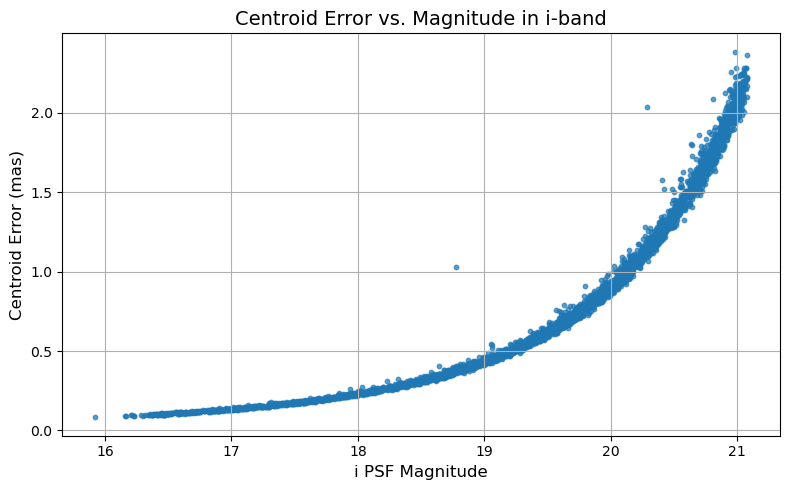

```python
plt.figure(figsize=(8, 5))
plt.scatter(mag, centroid_err, s=10, alpha=0.7)
plt.xlabel(f"{my_band} PSF Magnitude", fontsize=12)
plt.ylabel("Centroid Error (mas)", fontsize=12)
plt.title(f"Centroid Error vs. Magnitude in {my_band}-band", fontsize=14)
plt.grid(True)
plt.tight_layout()
plt.show()
```

> **Figure 2:** `SdssCentroid` errors as a function of *i*-band magnitude.

## 5. Notes on astrometric accuracy

The plots in Section 4 use the propagated uncertainties on the centroids from the `SdssCentroid` fit, which are not indicative of the overall astrometric accuracy. To assess the performance of the complete astrometric solution, internal and external consistency tests are performed.